# Using the Adult Weight Change Model

Rodrigo Zepeda Tello & Dalia Camacho García Formentí

2018-06-26

> In this vignette we explain how to use the model for adults in R; we develop and explain the equations involved both for casual and advanced readers.

# Contents

- Usage in R
- Basic model explanation
- Advanced model explanation

# Usage in R

The main inputs for the body weight change model in adults are:

| Input | Meaning | Optional | Default |
| --- | --- | --- | --- |
| `bw` | Body Weight (kg) | No | - |
| `ht` | Height (m) | No | - |
| `age` | Age (yrs) | No | - |
| `sex` | Either `'male'` or `'female'` | No | - |

As an example consider a `40` year old `'female'` weighting `80` kg with a height of `1.8` metres:

```r
female_model1 <- adult_weight(bw = 80, ht = 1.8, age = 40, sex = "female")
```

Furthermore, the model allows the user to input daily changes in sodium and energy intake compared to the baseline consumption (for example, if doing a diet which reduces `-100` kcals from previous consumption).

| Input | Meaning | Optional | Default |
| --- | --- | --- | --- |
| `EIchange` | Energy intake difference from baseline (kcal) | Yes | No energy change |
| `NAchange` | Sodium intake difference from baseline (kcal) | Yes | No sodium change |

Note that this `-100` kcals is not cummulative. For example, if an individual consumes daily `2000` kcals a `EIchange = -100` means that in day 1 the individual consumes `1900` kcals; in day 2 the individual consumes `1900` kcals; in day 3 the individual consumes `1900` kcals, etc.

For example, this female can reduce her energy consumption by `-250` kcals and her sodium intake by `20` mg:

```r
female_model2 <- adult_weight(bw = 80, ht = 1.8, age = 40, sex = "female",
                      EIchange = rep(-250, 365), NAchange = rep(-20, 365))
```

If no `NAchange` is inputed, the model assumes a `0` change:

```r
female_model3 <- adult_weight(bw = 80, ht = 1.8, age = 40, sex = "female",
                      EIchange = rep(-250, 365))
```

The same is true for `EIchange`.

Note that in the examples above, `EIchange = rep(-250, 365)` is inputed as a vector with each day representing the consumption reduction for that day. See Energy Reduction section for additional information

Other (optional) inputs include:

| Input | Meaning | Optional | Default |
| --- | --- | --- | --- |
| `EI` | Energy intake (kcal) at baseline | Yes | Model estimate |
| `fat` | Baseline fat mass (kg) of the individual | Yes | Model estimate |
| `PAL` | Physical activity level | Yes | $1.5$ |
| `pcarb_base` | % of baseline intake that is carbohydrates | Yes | $0.5$ |
| `pcarb` | % of intake after day $0$ that is carbohydrates | Yes | `pcarb_base` |

Hence the same female can consume `2000` kcals at baseline, with `22`kg of fat mass, having a physical activity level of `1.7` with a proportion of `0.6` kcals attributed to carbohydrates at baseline and a proportion of `0.5` kcals attributed to carbohydrates after dietary change.

```r
female_model4 <- adult_weight(bw = 80, ht = 1.8, age = 40, sex = "female",
                      EIchange = rep(-250, 365), EI = 2000, fat = 22,
                      PAL = 1.7, pcarb_base = 0.6, pcarb = 0.5)
```

Additional inputs include `days` to specify the model’s time span and `checkValues` which checks that the model’s results are biologically plausible (for example, that modelled body weight is always positive). All inputs used in the model are:

| Input | Meaning | Optional | Default |
| --- | --- | --- | --- |
| `bw` | Body Weight (kg) | No | - |
| `ht` | Height (m) | No | - |
| `age` | Age (yrs) | No | - |
| `sex` | Either `'male'` or `'female'` | No | - |
| `EIchange` | Energy intake difference from baseline (kcal) | Yes | No energy change |
| `NAchange` | Sodium intake difference from baseline (kcal) | Yes | No sodium change |
| `EI` | Energy intake (kcal) at baseline | Yes | Model estimate |
| `fat` | Fat mass (kg) of the individual | Yes | Model estimate |
| `PAL` | Physical activity level | Yes | $1.5$ |
| `pcarb_base` | % of baseline intake that is carbohydrates | Yes | $0.5$ |
| `pcarb` | % of intake after day $0$ that is carbohydrates | Yes | `pcarb_base` |
| `days` | Time period (days) to run the model | Yes | $365$ |
| `dt` | Time step for Rungue-Kutta 4 | Yes | $1$ |
| `checkValues` | Check for internal consistency | Yes | `TRUE` |

```r
#Database information
weights <- c(45, 67, 58, 92, 81)
heights <- c(1.30, 1.73, 1.77, 1.92, 1.73)
ages    <- c(45, 23, 66, 44, 23)
sexes   <- c("male", "female", "female", "male", "male")

#Returns a weight change matrix and other matrices
database_model <- adult_weight(weights, heights, ages, sexes)
```

## Plots

Result plots can be obtained by `model_plot` function:

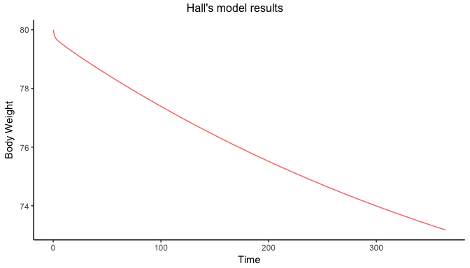

```r
model_plot(female_model2, "Body_Weight")
```

Plotting options include `"Body_Weight"`, `Fat_Mass`, `Lean_Mass`, `Glycogen`, `Extracellular_Fluid` and `Adaptive_Thermogenesis`. Several can be chosen at the same time:

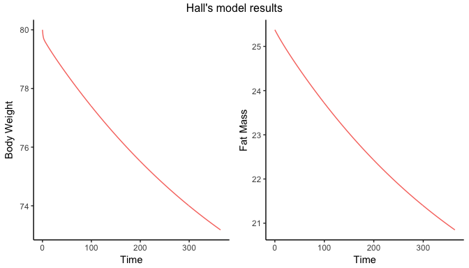

```r
model_plot(female_model2, c("Body_Weight", "Fat_Mass"))
```

Variables can also be plotted against age:

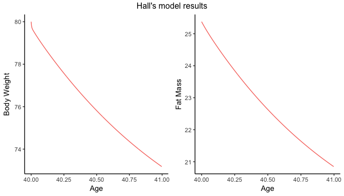

```r
model_plot(female_model2, c("Body_Weight", "Fat_Mass"), timevar = "Age")
```

## Energy Reduction

Energy intake change is usually not continuously measured but measured at different and distant points in time (say 1 year apart). The function `energy_build` allows the user to interpolate different energy models between the interpolation points. As an example consider an individual that by day `365` had reduced his consumption in `250` kcals and by day `730` had increased his consumption by `100` kcals (both compared to the consumption initially). The `energy_build` function interpolates those values via a Brownian Bridge:

```r
EIbrownian <- energy_build(c(0, -250, 100), c(0, 365, 730))
```

The interpolation looks like this:

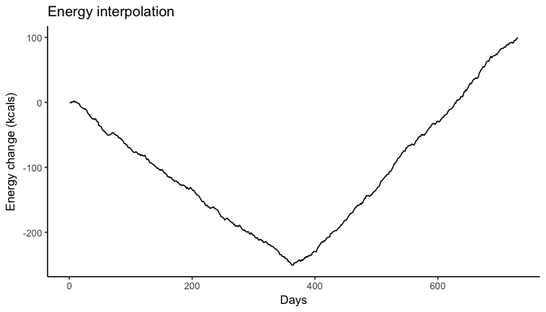

```r
ggplot() + geom_line(aes(x = 1:730, y = EI), data = data.frame(EI = EIbrownian)) +
  theme_classic() +
  xlab("Days") + ylab("Energy change (kcals)") + ggtitle("Energy interpolation")
```

Such energy change matrix can be directly inputed in the model:

```r
model_brownian <- adult_weight(70, 1.75, 22, "male", EIbrownian, days = 730)
```

Other interpolation modes include `Linear`, `Exponential`, `Stepwise_R` (right stepwise), `Stepwise_L` (left stepwise), and `Logarithmic`:

```r
EIlinear      <- energy_build(c(0, -250, 100), c(0, 365, 730), "Linear")
EIexponential <- energy_build(c(0, -250, 100), c(0, 365, 730), "Exponential")
EIstepwise_r  <- energy_build(c(0, -250, 100), c(0, 365, 730), "Stepwise_R")
EIstepwise_l  <- energy_build(c(0, -250, 100), c(0, 365, 730), "Stepwise_L")
EIlogarithmic <- energy_build(c(0, -250, 100), c(0, 365, 730), "Logarithmic")
```

Which look like this:

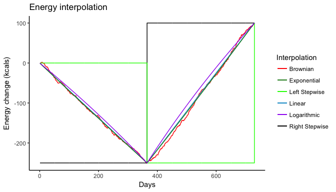

```r
ggplot() +
  geom_line(aes(x = 1:730, y = EI, color = "Brownian"),
            data = data.frame(EI = EIbrownian)) +
  geom_line(aes(x = 1:730, y = EI, color = "Linear"),
            data = data.frame(EI = EIlinear)) +
  geom_line(aes(x = 1:730, y = EI, color = "Exponential"),
            data = data.frame(EI = EIexponential)) +
  geom_step(aes(x = 1:730, y = EI, color = "Right Stepwise"),
            data = data.frame(EI = EIstepwise_r)) +
  geom_step(aes(x = 1:730, y = EI, color = "Left Stepwise"),
            data = data.frame(EI = EIstepwise_l)) +
  geom_line(aes(x = 1:730, y = EI, color = "Logarithmic"),
            data = data.frame(EI = EIlogarithmic)) +
  xlab("Days") + ylab("Energy change (kcals)") +
  ggtitle("Energy interpolation") +
  theme_classic() +
  scale_color_manual("Interpolation",
                     values = c("Brownian" = "red", "Linear" = "deepskyblue3",
                                "Exponential" = "forestgreen", "Logarithmic" = "purple",
                                "Right Stepwise" = "black", "Left Stepwise" = "green"))
```

These models result in different weight changes:

```r
model_linear      <- adult_weight(70, 1.75, 22, "male", EIlinear, days = 730)
model_exponential <- adult_weight(70, 1.75, 22, "male", EIexponential, days = 730)
model_logarithmic <- adult_weight(70, 1.75, 22, "male", EIlogarithmic, days = 730)
model_stepwise_r  <- adult_weight(70, 1.75, 22, "male", EIstepwise_r, days = 730)
model_stepwise_l  <- adult_weight(70, 1.75, 22, "male", EIstepwise_l, days = 730)
```

Which look as follows:

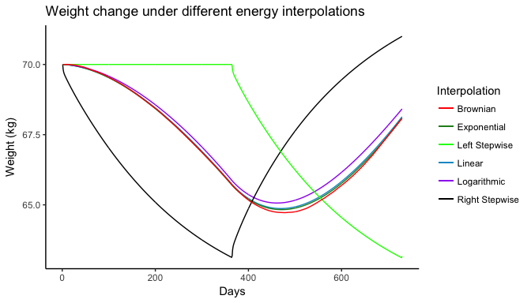

## Estimating weight change from a database

Vector data can also be used in the model to calculate weight change for several individuals at a time (which is quite faster than doing them individually in a `for` loop). As an example consider the following dataset:

```r
#Database information
mydata <- data.frame(
  id     = 1:5,
  weight = c(67, 68, 69, 70, 71),
  height = c(1.30, 1.73, 1.77, 1.92, 1.73),
  age    = c(45, 23, 66, 44, 23),
  sex    = c("male", "female", "female", "male", "male"),
  energy_change = runif(5, -200, 200),
  prob   = c(0.1, 0.2, 0.2, 0.05, 0.45))

#Get energy change with energy build function
eichange      <- energy_build(cbind(rep(0,5), mydata$energy_change), c(0, 365))

#Returns a weight change matrix and other matrices
database_model <- adult_weight(mydata$weight, mydata$height, mydata$age, mydata$sex,
                               eichange)
```

Plots can also be obtained for the population with the same command `model_plot`:

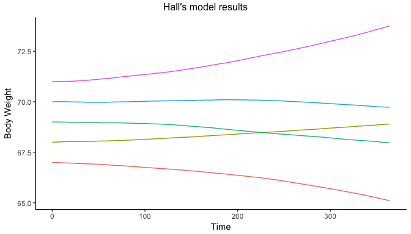

```r
model_plot(database_model, "Body_Weight")
```

Summary measures can be obtained via `model_mean` and `adult_bmi`. The first, quantifies mean for `'Body_Weight'`, `'Adaptive_Thermogenesis'`, `'Extracellular_Fluid'`, `'Age'`, `'Body_Mass_Index'`, `'Glycogen'`, `'Lean_Mass'`, and `'Fat_Mass'`:

```r
model_mean(database_model, "Body_Weight")
```

```
##   time    variable group     mean   SE_mean
## 1    0 Body_Weight     1 69.00000 0.7071068
## 2   15 Body_Weight     1 69.00096 0.7105065
## 3   30 Body_Weight     1 68.99825 0.7178304
## 4   45 Body_Weight     1 68.99902 0.7270534
## 5   60 Body_Weight     1 69.00760 0.7415572
## 6   75 Body_Weight     1 69.02158 0.7583163
```

Mean is only estimated for some points in time, to estimate mean for the whole period, consider changing the `days` vector variable:

```r
model_mean(database_model, "Body_Weight", days = 1:365)
```

```
##   time    variable group     mean   SE_mean
## 1    1 Body_Weight     1 68.99989 0.7071755
## 2    2 Body_Weight     1 69.00001 0.7073718
## 3    3 Body_Weight     1 69.00009 0.7076656
## 4    4 Body_Weight     1 69.00037 0.7079985
## 5    5 Body_Weight     1 69.00067 0.7082119
## 6    6 Body_Weight     1 69.00111 0.7082646
```

Mean can also be grouped by a variable (say, `sex`):

```r
model_mean(database_model, "Body_Weight", days = 1:365, group = mydata$sex)
```

```
##   time    variable  group     mean   SE_mean
## 1    1 Body_Weight female 68.50058 0.3947780
## 2    1 Body_Weight   male 69.33277 1.0974821
## 3    2 Body_Weight female 68.50114 0.3944845
## 4    2 Body_Weight   male 69.33259 1.0979748
## 5    3 Body_Weight female 68.50155 0.3938697
## 6    3 Body_Weight   male 69.33246 1.0986673
```

Finally, `model_mean` can also be used to estimate `survey` means using the `svydesign` from the `survey` package:

```r
require("survey")
design <- svydesign(ids = ~id, probs = ~prob, data = mydata)
model_mean(database_model, group = mydata$sex, design = design)
```

```
##   time               variable  group     mean    SE_mean
## 1    0                    Age female 44.50000 16.9972424
## 2    0                    Age   male 42.86207  1.8759782
## 3    0 Adaptive_Thermogenesis female  0.00000  0.0000000
## 4    0 Adaptive_Thermogenesis   male  0.00000  0.0000000
## 5    0    Extracellular_Fluid female 17.90450  0.1605646
## 6    0    Extracellular_Fluid   male 18.28450  2.1201364
```

The same process can be replicated with `adult_bmi` to obtain Body Mass Index prevalence per day:

```r
adult_bmi(database_model, group = mydata$sex)
```

```
##   Day  Group BMI_Category      Mean          NA        NA
## 1   0 female       Normal 1.0000000  1.00000000 1.0000000
## 2   0   male       Normal 0.6666667  0.07026862 1.2630647
## 3   0 female        Obese 0.0000000  0.00000000 0.0000000
## 4   0   male        Obese 0.3333333 -0.26306471 0.9297314
## 5  15 female       Normal 1.0000000  1.00000000 1.0000000
## 6  15   male       Normal 0.6666667  0.07026862 1.2630647
```

Additional information on the Children model and other package functions can be obtained in the other package’s Vignettes

```r
browseVignettes("bw")
```

# Basic explanation on model’s equations

The main idea of the adult dynamic weight change model (Chow and Hall 2008, Hall et al. (2011), Hall (2010), Hall and Jordan (2008)) is that body weight $BW(t)$ at a given time $t$ is the sum of four components: lean mass $L(t)$, fat mass $F(t)$, glycogen $g(t)$, and extracellular fluid $ECF(t)$:

$$\begin{equation}\label{bw}
\overbrace{BW(t)}^{\textrm{Weight}} = \underbrace{F(t)}_{\textrm{Fat}} + \overbrace{L(t)}^{\textrm{Lean}} + \underbrace{3.7 \cdot G(t)}_{\textrm{Glycogen and Associated water}} + \overbrace{ECF(t)}^{\textrm{Extracellular Fluid}}
\end{equation}$$

Lean mass, fat mass, and glycogen are interrelated, meanwhile the extracellular fluid has its own dynamic. The dynamic model’s equations are congruent with the energy conservation law. Changes in weight are therefore determined by:

- Energy intake ($EI$),
- Energy expenditure ($EE$),
- Glycogen reserve ($G$).

Changes in lean and fat mass are given by changes in intake, expenditure, and glycogen. An increase or decrease in body weight depends on the difference between intake and expenditure. A fraction of the change in weight $p$ will correspond to the change in lean mass and the remaining fraction $(1-p)$ will correspond to changes in fat mass. The corresponding equations are:

$$\begin{equation}\nonumber
\overbrace{\dfrac{dL}{dt}}^{\textrm{Change in lean mass}} = \underbrace{p}_{\textrm{Fraction}} \overbrace{\frac{\Big( EI - EE - \rho_G \frac{dG}{dt}\Big)}{\rho_L}}^{\textrm{Energy Intake} - \textrm{Expenditure+Storage}}
\end{equation}$$
$$\begin{equation}\nonumber
\overbrace{\dfrac{dF}{dt}}^{\textrm{Change in fat mass}} = \underbrace{(1-p)}_{\textrm{Remaining fraction}} \overbrace{\frac{\Big( EI - EE - \rho_G \frac{dG}{dt}\Big)}{\rho_L}}^{\textrm{Energy Intake} - \textrm{Expenditure+Storage}}
\end{equation}$$

Changes in glycogen are determined by the proportion of energy consumption from carbohydrats $CI$:

$$\begin{equation}
\overbrace{\dfrac{dG}{dt}}^{\textrm{Change in glycogen}} = \underbrace{\frac{1}{\rho_G} \Big( CI - k_G G^2\Big)}_{\textrm{Carbohydrates and constant parameters}},
\end{equation}$$
Finally, the equation for extracellular fluid depends on sodium intake and carbohydrats consumed:
$$\begin{equation}\nonumber
\overbrace{\dfrac{dECF}{dt}}^{\textrm{Change in fluid}} = \overbrace{\frac{ \Big( \Delta Na_{diet} + \xi_{Na}(ECF - ECF_{init}) - \xi_{CI} (1 - \frac{CI}{CI_{b}}) \Big)}{Na}.}^{\textrm{Depends on changes in sodium and carbohydrat intake.}}
\end{equation}$$

To summarize: weight is divided into four interdependent components: lean mass, fat mass, glycogen, and extracellular fluid. The weight change model describes the processes resulting from interconnections between the components:

$$\begin{equation}\label{bw2}
\overbrace{BW(t)}^{\textrm{Weight}} = \underbrace{F(t)}_{\textrm{Fat}} + \overbrace{L(t)}^{\textrm{Lean}} + \underbrace{3.7 \cdot G(t)}_{\textrm{Glycogen and Associated water}} + \overbrace{ECF(t)}^{\textrm{Extracellular Fluid}}
\end{equation}$$

# Advanced explanation on model’s equations

The dynamic weight change model Chow and Hall (2008) defines individual weight (kg) as the sum of fat $F$ and lean mass $L$, extracellular fluid $ECF$ and glycogen $G$:
$$\begin{equation}\label{bodyweight}
\begin{aligned}
BW = ECF + 3.7 G + F + L.
\end{aligned}
\end{equation}$$
Extracellular fluid $ECF \equiv ECF(t)$ is the solution to the ordinary differential equation system:
$$\begin{equation}\label{ecf}
\begin{cases}
\dfrac{dECF}{dt} & = \frac{1}{Na} \Big( \Delta Na_{diet} + \xi_{Na}(ECF - ECF_{init}) - \xi_{CI} (1 - CI /CI_{b}) \Big),\\\\
ECF_{init} & = 0.
\end{cases}
\end{equation}$$
where $Na = 3.22$ mg/ml, $\xi_{Na} = 3000$ mg/L/d, and $\xi_{CI} = 4000$ mg/d, are phisiological constants (Chow and Hall 2008). $\Delta Na_{diet}$ represents the change in sodium (mg/d) for the individual. $CI_b$ is the carbohydrate intake at baseline (assumed to be $1/2$ of energy intake estimated) and $CI \equiv CI(t)$ is the carbohydrate intake after the consumption reduction (assumed to be half the energy intake after reduction, $CI \equiv \Delta EI(t) / 2$). Glycogen mass $G \equiv G(t)$ is described by the ordinary differential equation:
$$\begin{equation}\label{gly}
\dfrac{dG}{dt} = \frac{1}{\rho_G} \Big( CI - k_G \cdot G^2\Big),
\end{equation}$$

where $\rho_G = 4206.501 \textrm{kcals}/\textrm{kg}$ ($17.6 MJ/kg$), and $k_G = CI_b/G_{init}^2$ is a constant with $G_{init} = 0.5$ kg the initial glycogen mass.

Fat and lean mass, $F\equiv F(t)$ and $L \equiv L(t)$, represent the solutions to the following system of nonlinear ordinary differential equations:
$$\begin{equation}\label{desolveadoras}
\begin{aligned}
\dfrac{dF}{dt} & = \frac{\big(1-p \big)}{\rho_F}\Big( EI_{\textrm{init}} - EE - \rho_G \frac{dG}{dt}\Big),\\
\dfrac{dL}{dt} & = \frac{p}{\rho_L}\Big( EI_{\textrm{init}} - EE - \rho_G \frac{dG}{dt}\Big),
\end{aligned}
\end{equation}$$
with $\rho_F = 9440.727$ kcals/kg ($39.5$ MJ/kg), $\rho_L = 1816.444$ kcals/kg ($7.6$ MJ/kg) are constants, and $p \equiv C/ (C+F)$ a function of fat mass with $C = 10.4 \cdot \rho_L \rho_F^{-1}$. Total energy expenditure $EE$ is given by:
$$\begin{equation}
EE = K + \gamma_F F + \gamma_L L + \delta BW + TEF + AT + \eta_L \dfrac{dL}{dt} + \eta_F \dfrac{dF}{dt} ,
\end{equation}$$
with $\gamma_F = 3.107075$ kcals/kg/d ($13$ kJ/kg/d), $\gamma_L = 21.98853$ kcals/kg/d ($92$ kJ/kg/d), $\eta_F = 179.2543$ kcals/kg ($750$ kJ/d), $\eta_L = 229.4455$ kcals/kg ($960$ kJ/kg) are physiological constants. $K$ is determined by the initial energy balance condition:
$$\begin{equation}\label{K}
K = RMR_{init} \cdot PAL - \gamma_L L_{init} - \gamma_F F_{init} - \delta BW_{init}
\end{equation}$$
with $RMR_{init}$ the initial resting metabolic rate, $PAL$ the physical activity level (assumed $PAL = 1.5$), $L_{init}, F_{init}, BW_{init}$ the initial lean, fat and body weight masses. The constant $\delta$ is determined defined as $\delta = RMR_{init} \Big( (1 - \beta_{TEF}) \cdot PAL - 1\Big) / BW_{init}$ with $\beta_{TEF} = 0.1$. Furthermore, the thermal effect of feeding is defined as $TEF \equiv \beta_{TEF} \Delta EI(t)$ with $\Delta EI(t)$ as previously specified. Finally, adaptative thermogenesis is given by the solution to the ODE system:
$$\begin{equation}\label{at}
\begin{cases}
\dfrac{dAT}{dt} & = \beta_{AT} \Delta EI - AT, \\ \\
AT_{init} & = \beta_{AT} \cdot PAL \cdot RMR_{init}.
\end{cases}
\end{equation}$$
We remark that for each individual, the initial resting metabolic rate $RMR_{init}$ is described by the equations Mifflin et al. (1990):
$$\begin{equation}\label{rmr}
RMR_{init} = \begin{cases}
9.99\cdot BW_{init} + 625\cdot H_{init} -4.92\cdot AGE_{init} + 5 & \text{if Sex $=$ Male}, \\
9.99\cdot BW_{init} + 625\cdot H_{init}-4.92\cdot \cdot AGE_{init} -161 & \text{if Sex $=$ Female}.
\end{cases}
\end{equation}$$
with $H_{init}$, $AGE_{init}$ initial height and age respectively. Initial fat mass was obtained via the function:
$$\begin{equation}\label{fatmass}
F_{init} = \begin{cases}
(1/100) \cdot BW_{init} \cdot \Big(0.14 \cdot AGE_{init} + 37.31 \times \ln(BW_{init} / H_{init}^2) - 103.94 \Big) & \text{if Sex $=$ Male} , \\
(1/100) \cdot BW_{init} \cdot \Big(0.14 \cdot AGE_{init} + 39.96 \cdot \ln(BW_{init} / H_{init}^2) - 102.01 \Big) & \text{if Sex $=$ Female}.
\end{cases}
\end{equation}$$

Additional information on the model can be found in (Chow and Hall 2008, Hall et al. (2011), Hall (2010), Hall and Jordan (2008))

## Solution algorithm

To solve this system of differential equations, we used a 4th order Runge-Kutta algorithm (RK4) Ascher and Greif (2011) with a stepsize $\Delta t = 1$. RK4 was programmed in `C++` for speed and connected to R via the `Rcpp` package (Eddelbuettel 2013, Eddelbuettel and François (2011)).

# Additional information

Additional information on the children’s model, and why to use the dynamic adult model instead of other classical approaches can be found in the package’s vignettes:

```r
browseVignettes("bw")
```

# References

Ascher, Uri M, and Chen Greif. 2011. *A First Course on Numerical Methods*. SIAM.

Chow, Carson C, and Kevin D Hall. 2008. “The Dynamics of Human Body Weight Change.” *PLoS Comput Biol* 4 (3): e1000045.

Eddelbuettel, Dirk. 2013. *Seamless R and C++ Integration with Rcpp*. New York: Springer.

Eddelbuettel, Dirk, and Romain François. 2011. “Rcpp: Seamless R and C++ Integration.” *Journal of Statistical Software* 40 (8): 1–18. http://www.jstatsoft.org/v40/i08/.

Hall, Kevin D. 2010. “Predicting Metabolic Adaptation, Body Weight Change, and Energy Intake in Humans.” *American Journal of Physiology-Endocrinology and Metabolism* 298 (3). Am Physiological Soc: E449–E466.

Hall, Kevin D, and Peter N Jordan. 2008. “Modeling Weight-Loss Maintenance to Help Prevent Body Weight Regain.” *The American Journal of Clinical Nutrition* 88 (6). Am Soc Nutrition: 1495–1503.

Hall, Kevin D, Gary Sacks, Dhruva Chandramohan, Carson C Chow, Y Claire Wang, Steven L Gortmaker, and Boyd A Swinburn. 2011. “Quantification of the Effect of Energy Imbalance on Bodyweight.” *The Lancet* 378 (9793). Elsevier: 826–37.

Mifflin, Mark D, Sachiko T St Jeor, Lisa A Hill, Barbara J Scott, Sandra A Daugherty, and YO Koh. 1990. “A New Predictive Equation for Resting Energy Expenditure in Healthy Individuals.” *The American Journal of Clinical Nutrition* 51 (2). Am Soc Nutrition: 241–47.